# Final lab in machine learning 57690

Menachem Sokolik and Valeria Lerman

16 7 2021

# Initialize

Load the imager package and use the following chunk in order to load an image.

## Libraries

[figure not shown]

```r
library(imager)
library(pls)
#Optimal K
library(factoextra)
#libraries for random forest classification
library(tuneRanger)
library(mlr)
library(OpenML)
library(randomForest)
library(ISLR)
library(ggplot2)
library(reshape2)
library(plyr)
library(dplyr)
#KNN
library(class)
library(gplots)
library(lattice)
library(caret)
# Set your working directory
#setwd('C:/Users/menac/OneDrive/Desktop/57690 Machine Learning Methods/final/')
im <- load.image("C://Users//VALER//Desktop//Cezanne.jpg")
# A painting!
plot(im)
```

And now let us look at the object we got. Its shape is

```r
dim(im)
```

```
## [1] 1600 1312    1    3
```

Last is the spectrum of the picture. It has a value of 3, representing RGB colors.

```r
print('head(5):')
```

```
## [1] "head(5):"
```

```r
im %>% as.data.frame() %>% head(5)
```

|  | x | y | cc | value |
| --- | --- | --- | --- | --- |
| 1 | 1 | 1 | 1 | 0.6352941 |
| 2 | 2 | 1 | 1 | 0.6392157 |
| 3 | 3 | 1 | 1 | 0.6823529 |
| 4 | 4 | 1 | 1 | 0.6666667 |
| 5 | 5 | 1 | 1 | 0.6470588 |

we first need to standardize our paintings into a fixed size.

[figure not shown]

```r
im2 <- resize(im, 500 ,500    ,1    ,3)
plot(im2)
```

```
im3 <- as.data.frame(im2)
image_Xs = im3$value
print(image_Xs[1:15])
```

## loading the data

```r
load("X_train.Rdata")
load("X_test.Rdata")
x.train <- data.frame(Xtrain1)
x.test <- data.frame(Xtest)
y_train<- read.csv('y_train.csv')
y_test<- read.csv('y_test.csv')
```

The following table summarizes the nationalities of the painters in our sample

```r
painters <- c("Cezanne", "Degas", "Gauguin", "Hassam", "Matisse", "Monet", "Pissarro", "Renoir", "Sargent", "VanGogh")
nationalities <- c("French", "French", "French", "US", "French", "French", "French", "French", "US", "Dutch")

df <- as.data.frame(cbind(painters, nationalities))
df
```

| painters | nationalities |
| --- | --- |
| Cezanne | French |
| Degas | French |
| Gauguin | French |
| Hassam | US |
| Matisse | French |
| Monet | French |
| Pissarro | French |
| Renoir | French |
| Sargent | US |
| VanGogh | Dutch |

## The data

```r
head(names(x.train),10)
```

```
##  [1] "X.1" "X"   "V1"  "V2"  "V3"  "V4"  "V5"  "V6"  "V7"  "V8"
```

```r
dim(x.train)
```

```
## [1]  3983 30002
```

3983 observations and 30002 parameters.

# PART 1:

## clustering by the optimal k (kmeans)

In this part, we preferred to use PCA model in order to reduce dimensions of our data. According to lecture 3, this approach projects p predictors into n- dimensional area, and n must be smaller than p. We use the projections to fit a linear regression model.

PCA is actually an orthogonal linear transformation of our data into a lower dimensional space, so that the biggest variance of each projection stands on the first principal component.

In the PCA model, it is very important to scale the variables if they are measured in different units, which means they also have different variances.

```r
#using prcomp in order to reduce the number of dimensions  (according to lab 4)
x_train <- prcomp(x.train[,-c(1,2)], scale = TRUE)

#In the PCA model, it is very important to scale the variables if they are measured in different units, which means they also have different variances.


#saving the results in csv files in order not to run the prcomp again, it takes a huge amount of time

write.csv(data.frame(x_train$x),"C:\\Users\\menac\\OneDrive\\Desktop\\57690 Machine Learning Methods\\final\\x_train$x.csv", row.names = FALSE)

write.csv(data.frame(x_train$sdev),"C:\\Users\\menac\\OneDrive\\Desktop\\57690 Machine Learning Methods\\final\\x_train$sdev.csv", row.names = FALSE)

#predict x.test using 300 pcs, after several attempts it gives the best accurancy
x_test.pca <- predict(x_train, newdata = x.test)[,1:300]
write.csv(data.frame(x_test.pca),"C:\\Users\\menac\\OneDrive\\Desktop\\57690 Machine Learning Methods\\final\\x_test.pca.csv", row.names = FALSE)
```

Note that after using the PCA function, we reduced drastically the dimensions of our data to 3983 x 3983 (with the smallest possible lost of the explained data)

```r
#reading the files to use them instead of running the function every time.
sdev <-  read.csv("x_train$sdev.csv")
```

```r
x_train_x <- read.csv("x_train$x.csv")
```

```r
#predict x.test using 300 pcs, after several attempts it gives the best accurancy
x_test.pca <- read.csv("x_test.pca.csv")
```

```r
pop.var.explained <- ((sdev^2/sum(sdev^2))) #  normalizing by the sum of all the PCs' variance
var.explained <- as.data.frame(pop.var.explained[order(pop.var.explained, decreasing = TRUE),])
#ordering the data frame in a decreasing order according to the explained variance.
colnames(var.explained) <- c("pop")
```

using the cumsum function in order to find the cumulative explained variance for every observation.

```r
cpvar <- cumsum(data.frame(cp=c(1:length(var.explained)),`prop`=var.explained*100))
cpvar$cp <- c(1:3983)
cpvar
```

| cp | pop |
| --- | --- |
| 1 | 28.60132 |
| 2 | 36.35115 |
| 3 | 40.22213 |
| 4 | 43.53220 |
| 5 | 46.14935 |
| 6 | 48.65483 |
| 7 | 50.06110 |
| 8 | 51.34034 |
| 9 | 52.40691 |
| 10 | 53.33365 |

[output cut: 3973 more lines]

creating a plot of cumulative explained variance proportion explained by number of PC: Note that we will need this plot in order to find how many pcs we should use in order to explain our data - we want to reduce their number as possible without affecting the results, in order to decrease the complexity of the model.

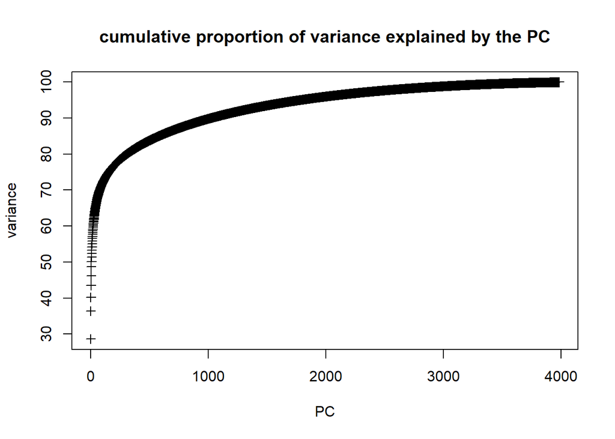

```r
plot(cpvar$cp, cpvar$pop,xlab="PC", ylab= "variance",main="cumulative proportion of variance explained by the PC", pch=3)
```

According to the plot, we can see that the variance explained by pc of 80% is good enough, so the pc number we use is 288.

Intuitively, since the number of nationalities of the painters is 3, we can assume that it’d be better to assign the observations to 3 clusters:

```r
k_mean2 <- kmeans(x_train_x, 3)
```

We prefer the kmeans function because our mission is to deal with unclasified data.

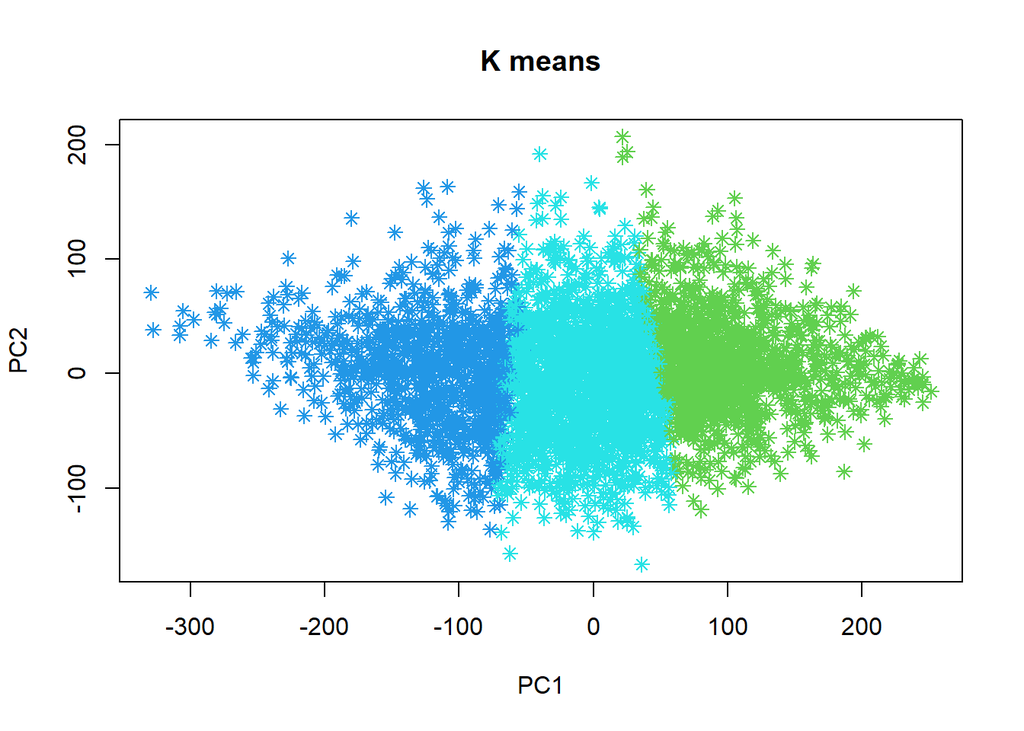

```r
plot(x_train_x[,1],x_train_x[,2], xlab = "PC1", ylab="PC2", main = "K means", pch=8, col=k_mean2$cluster+2)
```

However, if we use the built in function to find the optimal number of clusters, we find a different value…

Finding the optimal value of k for clustering

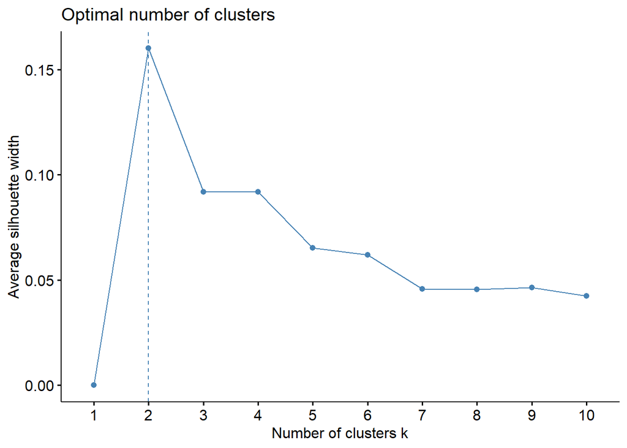

```r
fviz_nbclust(x_train_x, FUN=kmeans, method="silhouette")
```

Using kmeans function

```r
k_mean <- kmeans(x_train_x, 2)
```

Extract the withinss-cluster sum of squares

```r
knitr::kable(k_mean$withinss, caption = "k_mean withinss",col.names = NULL)
```

k_mean withinss

| 47552058 |
| --- |
| 49943106 |

The within-point scatter can be written as: $\sum _{k=1}^k\:\:n_k\sum \:_{c\left(i\right)=k}^{ }\:\:\left|| x_i-\overline{x_k}\right||^2$

Extract the between-cluster sum of squares

```r
knitr::kable(k_mean$betweenss, caption = "k_mean betweenss",col.names = NULL)
```

k_mean betweenss

| 21964836 |
| --- |

The similarity measure for any two observations is defined by the squared Euclidean distance.

```r
data.frame(cluster=k_mean$cluster)
```

| cluster |
| --- |
| 1 |
| 1 |
| 2 |
| 2 |
| 2 |
| 1 |
| 2 |
| 2 |
| 2 |
| 2 |

[output cut: 3973 more lines]

plotting the observations divided to 2 clusters according to optimal number k we found

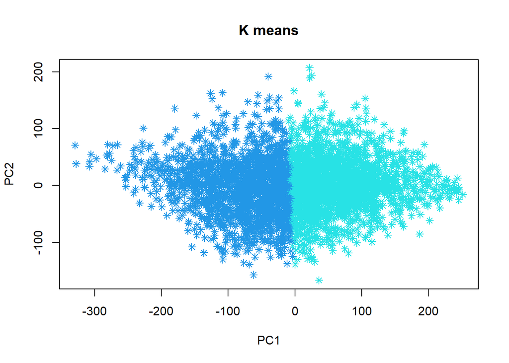

```r
plot(x_train_x[,1],x_train_x[,2], xlab = "PC1", ylab="PC2", main = "K means", pch=8, col=k_mean$cluster+3)
```

Even though the clusters are very close to each other, it can be seen quite clearly which cluster each observation belongs to, so the clustering proccess is a success.

A different way to prove that the optimal k is equal to 2:

creating a plot using fviz_nbclust function to find the optimal k value

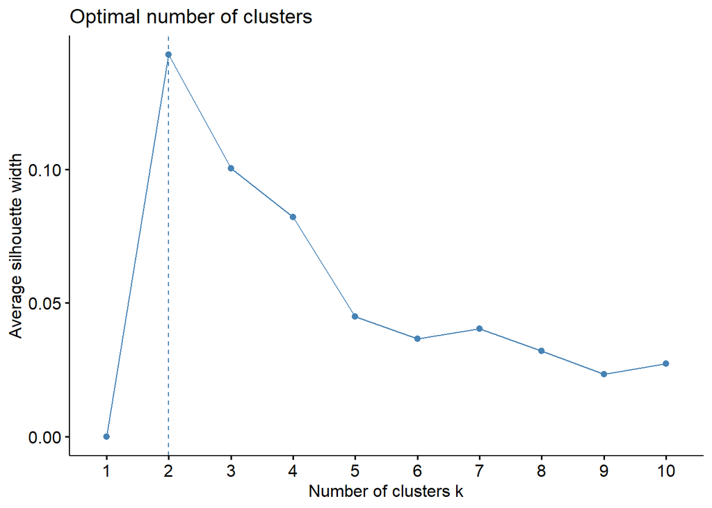

```r
dist_dat <- dist(x_train_x[,1:300])
hc_modle <- hclust(dist_dat,method = "complete")

fviz_nbclust(x_train_x[,1:300], FUN=hcut, method="silhouette")
```

```r
cutting <- cutree(hc_modle,2)
knitr::kable(table(cutting, y_train[,2]), caption = "k_mean betweenss")
```

| Cezanne | Degas | Gauguin | Hassam | Matisse | Monet | Pissarro | Renoir | Sargent | VanGogh |
| --- | --- | --- | --- | --- | --- | --- | --- | --- | --- |
| 104 | 79 | 69 | 256 | 176 | 244 | 197 | 91 | 111 | 218 |
| 290 | 319 | 330 | 143 | 223 | 155 | 201 | 308 | 288 | 181 |

As it can be seen from the plot above, the optimal number of clusters is really 2.

Why we chose to fit tree model instead of linear model to our data?

Classification to clusters fits better our data than a linear model, so its displayed graphically better and its very easy to explain the plot. But we should remember that trees are very sensitive to changes in the data while using them. When clustering the observations of our data, we try to divide them into different groups so the observations in every group are quite similar but the observations in different groups are different.

We define the number of clusters before clustering. Because all our variables are quantitative we can use kmeans clustering. Note that each observations is assigned to only one specific cluster. According to the kmeans function, we try to minimize the difference between the observations inside a cluster and to maximize the difference between the clusters.

# PART 2:

## Artwork Classification.

### KNN model:

The k-nearest neighbor regression method is a nonparametric method for predicting an outcome variable Y,based on a predictor X or a matrix of predictors X . Nonparametric methods do not explicitly assume a parametric form for f(X) so it provides a more flexible approach for making the regression regression.

How does the algorithm work?

The KNN algorithm holds the assumption that same observations are close to each other. In this model, the nearest neighbors are observations that have the shortest distance in the space from a new observation. K is the number of observations we want to check in the model. This means, that while applying KNN model we should take into account the distance between observations and the number of observations we want to look at.

Why we should use KNN model?

It’s quite intuitive model to explain. It gives quite high accuracy, relatively, but not as high as better supervised models. In addition, our mission is to cluster the observations, to assign a painter to each painting, so the KNN model is perfect for this kind of assignment. But KNN model can be slower and use more memory and place than other models, so if we have a lot of data it might be difficult to work with this model.

we chose to use 100 pcs after several attempts because it gave us the highest accuracy. Note that the optimal value for K will depend on the bias-variance tradeoff. A small value for K provides the most flexible fit, which has low bias and high variance, and as we increase k the bias will typically increase while the variance decreases. The number of neighbors k is inversely related to the model complexity.

We chose to use 100 pcs, which explains 72.2% of the variance, after several attempts, because it gave us a good prediction. Since there is a trade - off between the variance and bias when choosing the number we should be careful when increasing/decreasing it.

train/test sets

```r
train_data <- data.frame(x_train_x[,1:100])
train_data$class <- as.factor(y_train[,2])

test_data <- data.frame(x_test.pca[,1:100])
test_data$class <- as.factor(y_test[,2])

XTrain <- train_data[,-c(101)] #predictors only
XTest <- test_data[,-c(101)] #predictors only

YTrain  <- train_data$class #true train classification
YTest <- test_data$class #true test classification
```

A typical strategy to evaluate the performance of an algorithm with different values of the hyperparameters is k-fold cross-validation. The value of k is usually chosen between 2-10.

showing the best 15 combinations for cv dataset and training set with highest accuracy

```r
set.seed(20)
trControl.knn <- trainControl(method  = "cv", number  = 10)

fit.knn <- train(class~.,
             method     = "knn",
             tuneLength = 15,
             trControl  = trControl.knn,
             metric     = "Accuracy",
             data       = train_data)


fit_cv.knn <- data.frame(fit.knn$results) %>% arrange(desc(Accuracy))

k <- fit.knn$bestTune

write.csv(data.frame(fit_cv.knn),"C://Users//VALER//Desktop//fit_cv.knn.csv", row.names = FALSE)
head(fit_cv.knn,15)
```

|  | k | Accuracy | Kappa | AccuracySD | KappaSD |
| --- | --- | --- | --- | --- | --- |
| 1 | 27 | 0.2894737 | 0.2105644 | 0.02596432 | 0.02886951 |
| 2 | 25 | 0.2887237 | 0.2097243 | 0.02049957 | 0.02278733 |
| 3 | 31 | 0.2877086 | 0.2086166 | 0.02541376 | 0.02829373 |
| 4 | 23 | 0.2862187 | 0.2069466 | 0.02182420 | 0.02428420 |
| 5 | 33 | 0.2854536 | 0.2061118 | 0.02229065 | 0.02479081 |
| 6 | 17 | 0.2847130 | 0.2052682 | 0.02312416 | 0.02574017 |
| 7 | 29 | 0.2844568 | 0.2050010 | 0.02414776 | 0.02687069 |
| 8 | 19 | 0.2837017 | 0.2041421 | 0.02182175 | 0.02428360 |
| 9 | 21 | 0.2827011 | 0.2030373 | 0.02151440 | 0.02395408 |
| 10 | 15 | 0.2801885 | 0.2002372 | 0.02279291 | 0.02535393 |

[output cut: 5 more lines]

```r
fit_cv.knn <- read.csv("fit_cv.knn.csv")
```

plot of k vs accuracy.

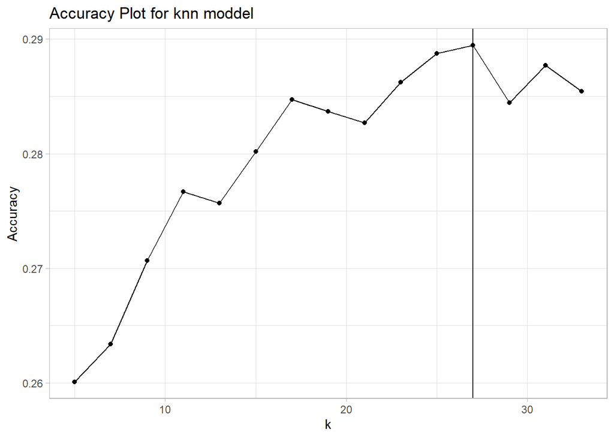

```r
ggplot(data=fit_cv.knn,aes(k, Accuracy)) +geom_point() +geom_line() + ggtitle("Accuracy Plot for knn moddel") +geom_vline(xintercept = 27) + theme_light()
```

knn results

```r
# predict for test  by optimal k
predicted.test.knn <- predict(fit.knn, XTest)  %>% as.factor
knn.Confusion.Matrix.test <- confusionMatrix(predicted.test.knn, as.factor(YTest))

knitr::kable(knn.Confusion.Matrix.test$table, caption = "confusion matrix of test")
```

confusion matrix of test

|  | Cezanne | Degas | Gauguin | Hassam | Matisse | Monet | Pissarro | Renoir | Sargent | VanGogh |
| --- | --- | --- | --- | --- | --- | --- | --- | --- | --- | --- |
| Cezanne | 36 | 9 | 10 | 3 | 10 | 8 | 11 | 7 | 8 | 11 |
| Degas | 3 | 25 | 5 | 2 | 4 | 2 | 5 | 8 | 10 | 2 |
| Gauguin | 10 | 11 | 31 | 5 | 2 | 8 | 6 | 9 | 5 | 6 |
| Hassam | 1 | 3 | 1 | 5 | 4 | 4 | 2 | 4 | 2 | 2 |
| Matisse | 1 | 3 | 1 | 2 | 6 | 0 | 0 | 2 | 2 | 1 |
| Monet | 20 | 20 | 10 | 51 | 46 | 58 | 17 | 16 | 24 | 12 |
| Pissarro | 12 | 8 | 21 | 16 | 12 | 11 | 54 | 17 | 9 | 20 |
| Renoir | 2 | 10 | 14 | 2 | 2 | 1 | 2 | 31 | 5 | 1 |
| Sargent | 2 | 5 | 0 | 0 | 0 | 1 | 0 | 0 | 21 | 4 |
| VanGogh | 12 | 5 | 6 | 13 | 13 | 6 | 2 | 5 | 13 | 40 |

```r
knitr::kable(prop.table(knn.Confusion.Matrix.test$table, 2), caption = "prop confusion matrix of test")
```

prop confusion matrix of test

|  | Cezanne | Degas | Gauguin | Hassam | Matisse | Monet | Pissarro | Renoir | Sargent | VanGogh |
| --- | --- | --- | --- | --- | --- | --- | --- | --- | --- | --- |
| Cezanne | 0.3636364 | 0.0909091 | 0.1010101 | 0.0303030 | 0.1010101 | 0.0808081 | 0.1111111 | 0.0707071 | 0.0808081 | 0.1111111 |
| Degas | 0.0303030 | 0.2525253 | 0.0505051 | 0.0202020 | 0.0404040 | 0.0202020 | 0.0505051 | 0.0808081 | 0.1010101 | 0.0202020 |
| Gauguin | 0.1010101 | 0.1111111 | 0.3131313 | 0.0505051 | 0.0202020 | 0.0808081 | 0.0606061 | 0.0909091 | 0.0505051 | 0.0606061 |
| Hassam | 0.0101010 | 0.0303030 | 0.0101010 | 0.0505051 | 0.0404040 | 0.0404040 | 0.0202020 | 0.0404040 | 0.0202020 | 0.0202020 |
| Matisse | 0.0101010 | 0.0303030 | 0.0101010 | 0.0202020 | 0.0606061 | 0.0000000 | 0.0000000 | 0.0202020 | 0.0202020 | 0.0101010 |
| Monet | 0.2020202 | 0.2020202 | 0.1010101 | 0.5151515 | 0.4646465 | 0.5858586 | 0.1717172 | 0.1616162 | 0.2424242 | 0.1212121 |
| Pissarro | 0.1212121 | 0.0808081 | 0.2121212 | 0.1616162 | 0.1212121 | 0.1111111 | 0.5454545 | 0.1717172 | 0.0909091 | 0.2020202 |
| Renoir | 0.0202020 | 0.1010101 | 0.1414141 | 0.0202020 | 0.0202020 | 0.0101010 | 0.0202020 | 0.3131313 | 0.0505051 | 0.0101010 |
| Sargent | 0.0202020 | 0.0505051 | 0.0000000 | 0.0000000 | 0.0000000 | 0.0101010 | 0.0000000 | 0.0000000 | 0.2121212 | 0.0404040 |
| VanGogh | 0.1212121 | 0.0505051 | 0.0606061 | 0.1313131 | 0.1313131 | 0.0606061 | 0.0202020 | 0.0505051 | 0.1313131 | 0.4040404 |

```r
knitr::kable(knn.Confusion.Matrix.test$overall[1], caption = "knn test Accuracy rate",col.names = NULL)
```

knn test Accuracy rate

| Accuracy | 0.310101 |
| --- | --- |

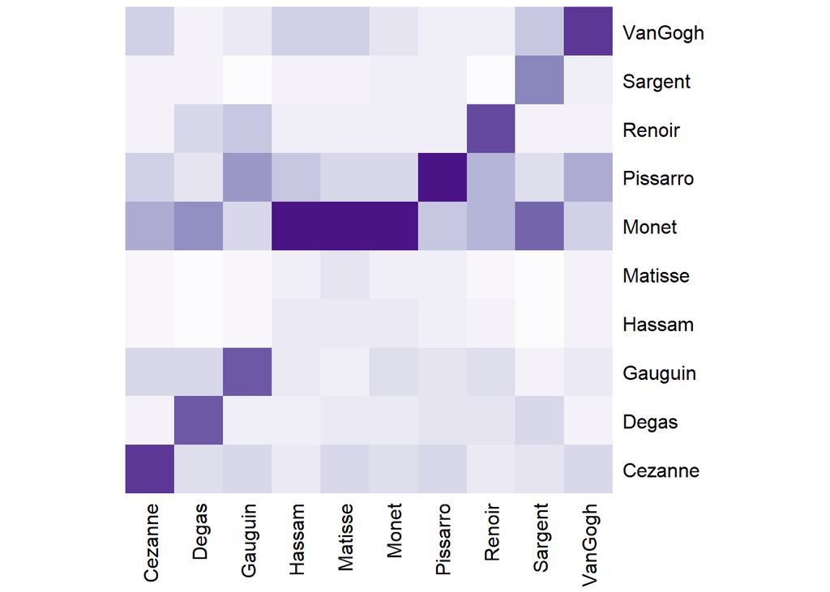

```r
library(RColorBrewer)
z = as.matrix(prop.table(knn.Confusion.Matrix.test$table, 2))
heatmap(z,Colv = NA, Rowv = NA, scale="column", col = colorRampPalette(brewer.pal(8, "Purples"))(25))
```

### RANDOM FOREST model:

In the random forest model, we build a number of decision trees on bootstrapped training samples, and then “decorrelate” them, trying to decrease the variance of the average.

How does it work?

we create multiple decision trees in a model, and we try to find the best tree. To classify a new observation with new attributes, every tree gives a classification. The forest chooses the classifications having the most votes of all the rest of trees, based on the importance score and takes the average difference from the output of different trees. In other words, this model creates multiple trees and unites them to achieve a more precise result.

While building trees the model divides into different subtrees, Then it looks for the best result from the random subsets. Thats why, only the random subset is taken into consideration in random forest model. Each tree in the random forests is identically distributed, so the Bias of an average of trees is the same as the Bias of any one of them. We hope to improve through variance reduction. The decrease in accuracy is averaged over all trees and serves as a measure for variable importance.

Why we should use this model? To begin with, we dicided to use RF after reading the article about tuning and using the suggested code on page 9 - it gave us a clue to use RF after tuning the reduced data.

In addition, RF has several advantages: It provides higher accuracy through cross validation, and can deal with a big set of data while still keeping a high accuracy. It will handle the missing values and maintain the accuracy of a large proportion of data, which is important because we have a lot of observations and we use quit a high percentage of it. If there are more trees, it avoids over-fitting trees in the model (which can help to get a higher accurancy) It has the power to handle a large data set with higher dimensionality

Tuning according to the given article, page 9: (Note that RF gives quite high accuracy rate even before performing the tuning proccess).

in order to make the tuning proccess properly, we should choose the correct hyperparameters to get the highest possible accuracy rate. Firstly we should choose the number of drawn candidate variables in each split, for the mtry. Note that lower values of mtry lead to more different, less correlated trees, yielding better stability when aggregating. On the other hand, larger mtry values leads to much higher magnitudes of the variable importances. But lower values of mtry also lead to trees that perform on average worse. Secondly, we choose the nodesize value, when setting it lower leads to trees with larger depth, which means it’ll take more time to run the proccess. Thirdly, we choose the number of trees value. Note that it should be quite high for stable variable importance estimates.

The aim of the tuning proccess is to find the optimal hyperparameters for a learning algorithm for our data.

In random forest model, we used the out-of-bag observations to evaluate the trained algorithm.

```r
train_dat <- data.frame(x_train_x[,1:77])
train_dat$class <- as.factor(y_train[,2])

test_dat <- data.frame(x_test.pca[,1:77])
test_dat$class <- as.factor(y_test[,2])
```

control case for random forest.

```r
set.seed(20)
trControl.rf <- trainControl(method  = "cv", number  = 10)

fit.rf <- train(class~.,
             method     = "rf",
             tuneLength = 15,
             trControl  = trControl.rf,
             metric     = "Accuracy",
             data       = train_dat)
print(fit.rf)
```

```
## Random Forest
##
## 3983 samples
##   77 predictor
##   10 classes: 'Cezanne', 'Degas', 'Gauguin', 'Hassam', 'Matisse', 'Monet', 'Pissarro', 'Renoir', 'Sargent', 'VanGogh'
##
## No pre-processing
## Resampling: Cross-Validated (10 fold)
## Summary of sample sizes: 3586, 3585, 3584, 3584, 3585, 3584, ...
## Resampling results across tuning parameters:
##
##   mtry  Accuracy   Kappa
##    2    0.3587988  0.2875412
##    7    0.3613096  0.2903266
##   12    0.3653328  0.2947979
##   18    0.3595413  0.2883768
##   23    0.3610482  0.2900484
##   28    0.3585363  0.2872533
##   34    0.3572951  0.2858872
##   39    0.3540300  0.2822432
##   44    0.3530160  0.2811234
##   50    0.3515143  0.2794543
##   55    0.3500017  0.2777762
##   60    0.3494909  0.2772111
##   66    0.3454834  0.2727598
##   71    0.3442423  0.2713763
##   77    0.3422398  0.2691536
##
## Accuracy was used to select the optimal model using the largest value.
## The final value used for the model was mtry = 12.
```

```r
fit_cv.rf <- data.frame(fit.rf$results)%>%arrange(desc(Accuracy))
write.csv(data.frame(fit_cv.rf),"C://Users//VALER//Desktop//fit_cv.rf.csv", row.names = FALSE)

finalModel.rf <- fit.rf$finalModel
```

showing the best 15 combinations, in a descending order:

```r
fit_cv.rf <- read.csv("fit_cv.rf.csv")
head(fit_cv.rf,15)
```

|  | mtry | Accuracy | Kappa | AccuracySD | KappaSD |
| --- | --- | --- | --- | --- | --- |
| 1 | 12 | 0.3653328 | 0.2947979 | 0.02228297 | 0.02472734 |
| 2 | 7 | 0.3613096 | 0.2903266 | 0.01982068 | 0.02200650 |
| 3 | 23 | 0.3610482 | 0.2900484 | 0.02237933 | 0.02483475 |
| 4 | 18 | 0.3595413 | 0.2883768 | 0.02173702 | 0.02413097 |
| 5 | 2 | 0.3587988 | 0.2875412 | 0.02716771 | 0.03017658 |
| 6 | 28 | 0.3585363 | 0.2872533 | 0.02128057 | 0.02361549 |
| 7 | 34 | 0.3572951 | 0.2858872 | 0.02056180 | 0.02280277 |
| 8 | 39 | 0.3540300 | 0.2822432 | 0.01595092 | 0.01768350 |
| 9 | 44 | 0.3530160 | 0.2811234 | 0.01957462 | 0.02172604 |
| 10 | 50 | 0.3515143 | 0.2794543 | 0.02066498 | 0.02293975 |

[output cut: 5 more lines]

```r
finalModel.rf
```

```
##
## Call:
##  randomForest(x = x, y = y, mtry = min(param$mtry, ncol(x)))
##                Type of random forest: classification
##                      Number of trees: 500
## No. of variables tried at each split: 12
##
##         OOB estimate of  error rate: 63.95%
## Confusion matrix:
##          Cezanne Degas Gauguin Hassam Matisse Monet Pissarro Renoir Sargent
## Cezanne      129    16      59     22      22    29       35     16      27
## Degas         23    85      67      9      47    18       32     57      31
## Gauguin       34    44     135     20      24    12       40     53      15
## Hassam        21    11      35    143      28    68       39      9      10
## Matisse       35    27      20     44     151    40       17     20      19
## Monet         26    15      17     61      18   177       45      9       3
## Pissarro      29    19      44     30       8    37      181     21       6
## Renoir        25    33      50     21      34     8       30    148      32
## Sargent       27    19      41     26      46    21       20     28     137
## VanGogh       36    24      31     33      18    38       32     14      23
##          VanGogh class.error
## Cezanne       39   0.6725888
## Degas         29   0.7864322
## Gauguin       22   0.6616541
## Hassam        35   0.6416040
## Matisse       26   0.6215539
## Monet         28   0.5563910
## Pissarro      23   0.5452261
## Renoir        18   0.6290727
## Sargent       34   0.6566416
## VanGogh      150   0.6240602
```

polt for mtry vs accuracy.

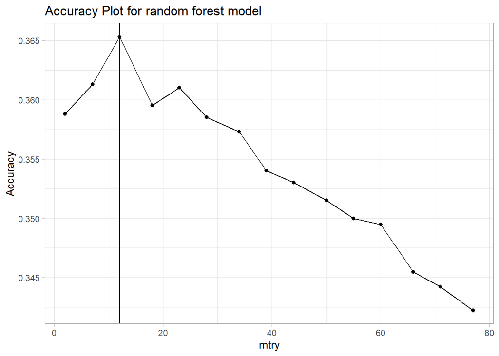

```r
ggplot(data=fit_cv.rf,aes(mtry, Accuracy)) +geom_point() +geom_line() + ggtitle("Accuracy Plot for random forest model") +geom_vline(xintercept = 12) + theme_light()
```

Tuning according to the given article, page 9 We decided to focus mtry, sample size and ntree as explained above.

I will use the method that presented in the article.

```r
monk_data_1 = train_dat
monk.task = makeClassifTask(data = monk_data_1, target = "y")
estimateTimeTuneRanger(monk.task)
set.seed(42)
# Tuning
res = tuneRanger(monk.task, measure = list(acc), num.trees = 2000,
num.threads = 2, iters = 70, iters.warmup = 30)
res

# Ranger Model with the new tuned hyperparameters
res$results

#saving the recommended.pars to use it later in the random forest model creation
res$recommended.pars

#saving the results in csv file in order not to run tuning again.
csv_file<-res$results%>%arrange(desc(acc))
write.csv(csv_file,"C://Users//VALER//Desktop//res$results.csv", row.names = FALSE)
```

arranging the data frame in descending order by accurancy and saving in csv file

```r
res_results<-read.csv("res$results.csv")
res_results
```

| mtry | min.node.size | sample.fraction | acc | exec.time |
| --- | --- | --- | --- | --- |
| 29 | 2 | 0.4830004 | 0.3700728 | 71.78 |
| 16 | 2 | 0.6718548 | 0.3690685 | 62.16 |
| 25 | 2 | 0.5094668 | 0.3690685 | 66.94 |
| 30 | 2 | 0.4733684 | 0.3688175 | 66.40 |
| 19 | 2 | 0.4847054 | 0.3675621 | 51.85 |
| 29 | 2 | 0.5457405 | 0.3675621 | 86.22 |
| 26 | 2 | 0.5018808 | 0.3673111 | 68.20 |
| 27 | 2 | 0.4578266 | 0.3673111 | 59.15 |
| 29 | 2 | 0.5562632 | 0.3665579 | 86.21 |
| 28 | 2 | 0.5547878 | 0.3665579 | 70.64 |

[output cut: 90 more lines]

now predict on test data.

```r
#creating the random forest model using the recommended.pars after cross validation
RF_fit <- randomForest(class~.,data= train_data, mtry= 29, node_size= 2,ntree=round(0.4830004*nrow(train_data)))
rf_pred <- predict(RF_fit, newdata = x_test.pca, type="class") #predict on the test set
#rf_pred <- predict(fit.rf, newdata = x_test.pca) #predict on the test set

#confusion matrix
conf.matrix.rf <- confusionMatrix(rf_pred, as.factor(test_dat$class))
#conf.matrix.rf <- table(predicted = rf_pred, actual = y_test[,2]) #confusion matrix

knitr::kable(conf.matrix.rf$overall, caption = "rf test overall rate",col.names = NULL)
```

rf test overall rate

| Accuracy | 0.3545455 |
| --- | --- |
| Kappa | 0.2828283 |
| AccuracyLower | 0.3247117 |
| AccuracyUpper | 0.3852473 |
| AccuracyNull | 0.1000000 |
| AccuracyPValue | 0.0000000 |
| McnemarPValue | 0.0000003 |

```r
knitr::kable(conf.matrix.rf$overall[1], caption = "rf test Accuracy rate",col.names = NULL)
```

rf test Accuracy rate

| Accuracy | 0.3545455 |
| --- | --- |

```r
#prop confusion matrix of test
knitr::kable(conf.matrix.rf$table, caption = "rf confusion matrix of test")
```

rf confusion matrix of test

|  | Cezanne | Degas | Gauguin | Hassam | Matisse | Monet | Pissarro | Renoir | Sargent | VanGogh |
| --- | --- | --- | --- | --- | --- | --- | --- | --- | --- | --- |
| Cezanne | 30 | 3 | 7 | 4 | 6 | 9 | 8 | 7 | 7 | 6 |
| Degas | 7 | 20 | 7 | 1 | 4 | 3 | 2 | 3 | 5 | 3 |
| Gauguin | 15 | 17 | 40 | 7 | 5 | 8 | 13 | 13 | 7 | 11 |
| Hassam | 3 | 6 | 6 | 29 | 12 | 12 | 7 | 10 | 7 | 7 |
| Matisse | 4 | 11 | 6 | 11 | 32 | 1 | 2 | 6 | 14 | 5 |
| Monet | 10 | 4 | 1 | 20 | 15 | 43 | 6 | 3 | 7 | 8 |
| Pissarro | 4 | 3 | 11 | 11 | 9 | 13 | 49 | 11 | 7 | 11 |
| Renoir | 5 | 20 | 13 | 5 | 4 | 3 | 3 | 40 | 8 | 4 |
| Sargent | 6 | 4 | 1 | 1 | 2 | 4 | 3 | 4 | 26 | 2 |
| VanGogh | 15 | 11 | 7 | 10 | 10 | 3 | 6 | 2 | 11 | 42 |

```r
knitr::kable(prop.table(conf.matrix.rf$table, 2), caption = "rfprop confusion matrix of test")
```

rfprop confusion matrix of test

|  | Cezanne | Degas | Gauguin | Hassam | Matisse | Monet | Pissarro | Renoir | Sargent | VanGogh |
| --- | --- | --- | --- | --- | --- | --- | --- | --- | --- | --- |
| Cezanne | 0.3030303 | 0.0303030 | 0.0707071 | 0.0404040 | 0.0606061 | 0.0909091 | 0.0808081 | 0.0707071 | 0.0707071 | 0.0606061 |
| Degas | 0.0707071 | 0.2020202 | 0.0707071 | 0.0101010 | 0.0404040 | 0.0303030 | 0.0202020 | 0.0303030 | 0.0505051 | 0.0303030 |
| Gauguin | 0.1515152 | 0.1717172 | 0.4040404 | 0.0707071 | 0.0505051 | 0.0808081 | 0.1313131 | 0.1313131 | 0.0707071 | 0.1111111 |
| Hassam | 0.0303030 | 0.0606061 | 0.0606061 | 0.2929293 | 0.1212121 | 0.1212121 | 0.0707071 | 0.1010101 | 0.0707071 | 0.0707071 |
| Matisse | 0.0404040 | 0.1111111 | 0.0606061 | 0.1111111 | 0.3232323 | 0.0101010 | 0.0202020 | 0.0606061 | 0.1414141 | 0.0505051 |
| Monet | 0.1010101 | 0.0404040 | 0.0101010 | 0.2020202 | 0.1515152 | 0.4343434 | 0.0606061 | 0.0303030 | 0.0707071 | 0.0808081 |
| Pissarro | 0.0404040 | 0.0303030 | 0.1111111 | 0.1111111 | 0.0909091 | 0.1313131 | 0.4949495 | 0.1111111 | 0.0707071 | 0.1111111 |
| Renoir | 0.0505051 | 0.2020202 | 0.1313131 | 0.0505051 | 0.0404040 | 0.0303030 | 0.0303030 | 0.4040404 | 0.0808081 | 0.0404040 |
| Sargent | 0.0606061 | 0.0404040 | 0.0101010 | 0.0101010 | 0.0202020 | 0.0404040 | 0.0303030 | 0.0404040 | 0.2626263 | 0.0202020 |
| VanGogh | 0.1515152 | 0.1111111 | 0.0707071 | 0.1010101 | 0.1010101 | 0.0303030 | 0.0606061 | 0.0202020 | 0.1111111 | 0.4242424 |

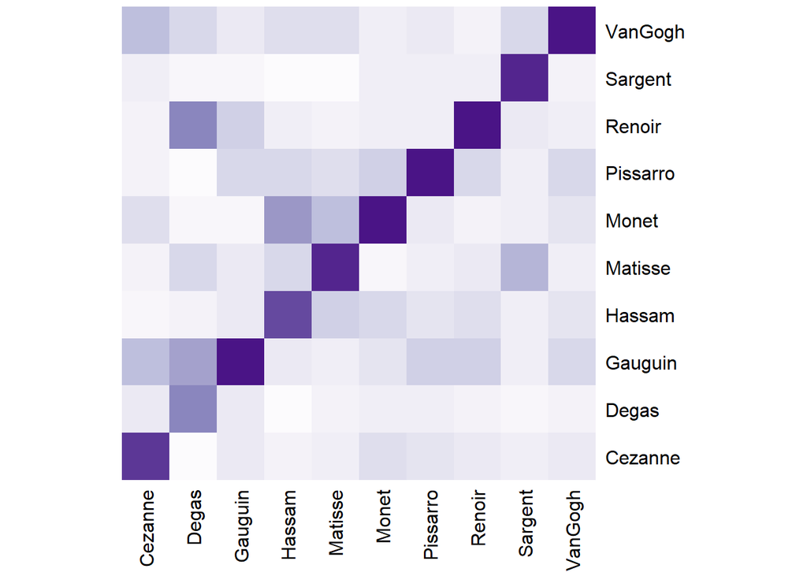

```r
library(RColorBrewer)
z = as.matrix(prop.table(conf.matrix.rf$table, 2))
heatmap(z,Colv = NA, Rowv = NA, scale="column", col = colorRampPalette(brewer.pal(8, "Purples"))(25))
```

So which one of the models we should prefer for the assignment?

According to the final accuracy tables of both models, it is easy to see that the Random Forest model gives a higher accuracy, just as we explained it would be above. In addition, RF model runs faster than the KNN model and uses less memory and space, since it uses random trees and recursion method. In conclusion, even so KNN model is simpler t understanding and fits perfectly to our mission, we suppose that in terms of time, memory and accuracy rate Random Forest is better than KNN model.

In addition, we would like to mention that we could probably get a little bit higher accuracy in both models by changing (increasing/decreasing) the parameters, for example in RF we could change the number of trees and the percentage of explained variance we want to get to, and in KNN model we could change the number of folds, the k value and the interval.

Conclusions according to the confusion matrices: We saw that both models confused between pairs of painters, and there is a logical reason for that- There are pictures which have very similar colors and similar shades, so when we turn them into vectors by defining them by 3 colors (red, green,blue), we receive a very high correlation between the pictures. So similar pictures with high correlations have a bigger chance to be confused with each other when predicting on the test.

Finally, we’d like to remind that we didn’t run some of the chunks during the knit, since we saved most of the results in csv files in order not to run everything again.. So those codes and chunks appear only in the RMD file.

BIBLIOGRAPHY:

tuning in KNN model

https://stats.stackexchange.com/questions/318968/knn-and-k-folding-in-r

information about RF model

https://www.newgenapps.com/blogs/random-forest-analysis-in-ml-and-when-to-use-it-2/#:~:text=Why%20use%20Random%20Forest%20Algorithm&text=Random%20forest%20algorithm%20can%20be,a%20large%20proportion%20of%20data.

https://www.r-bloggers.com/2020/01/product-price-prediction-a-tidy-hyperparameter-tuning-and-cross-validation-tutorial/

Article about tuning

https://arxiv.org/pdf/1804.03515.pdf

Predictive Modeling with PCA Components

https://www.analyticsvidhya.com/blog/2016/03/pca-practical-guide-principal-component-analysis-python/

Creating heatmap

https://www.r-graph-gallery.com/215-the-heatmap-function.html